# Lecture 5: Working with Data Part 1

Nick Huntington-Klein

January 18, 2019

## Working with Data

- R is all about working with data!
- Today we’re going to start going over the use of data.frames and tibbles
- data.frames are an object type; tibbles are basically data.frames with some extra bells and whistles, from the *tidyverse* package
- Most of the time, you’ll be doing calculations using them

## The Basic Idea

- Conceptually, data.frames are basically spreadsheets
- Technically, they’re a list of vectors

Spreadsheet

data.frame

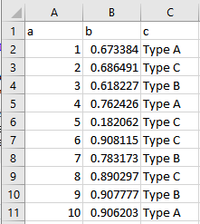

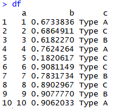

## Example

- It’s a list of vectors… we can make one by listing some (same-length) vectors!
- (Note the use of = here, not <-)

```r
df <- data.frame(RacePosition = 1:5,
                 WayTheySayHi = as.factor(c('Hi','Hello','Hey','Yo','Hi')),
                 NumberofKids = c(3,5,1,0,2))
df <- tibble(RacePosition = 1:5,
                 WayTheySayHi = as.factor(c('Hi','Hello','Hey','Yo','Hi')),
                 NumberofKids = c(3,5,1,0,2))
df
```

```
## # A tibble: 5 x 3
##   RacePosition WayTheySayHi NumberofKids
##          <int> <fct>               <dbl>
## 1            1 Hi                      3
## 2            2 Hello                   5
## 3            3 Hey                     1
## 4            4 Yo                      0
## 5            5 Hi                      2
```

## Looking Over Data

- Now that we have our data, how can we take a look at it?
- We can just name it in the Console and look at the whole thing, but that’s usually too much data
- We can look at the whole thing by clicking on it in Environment to open it up

## Glancing at Data

- What if we just want a quick overview, rather than looking at the whole spreadsheet?
  - Down-arrow in the Environment tab
  - `head()` (look at the head of the data - first six rows)
  - `str()` (structure)

```r
str(df)
```

```
## Classes 'tbl_df', 'tbl' and 'data.frame':    5 obs. of  3 variables:
##  $ RacePosition: int  1 2 3 4 5
##  $ WayTheySayHi: Factor w/ 4 levels "Hello","Hey",..: 3 1 2 4 3
##  $ NumberofKids: num  3 5 1 0 2
```

## So What?

- What do we want to know about our data?
  - What is this data OF? (won’t get that with `str()`)
  - Data types
  - The kinds of values it takes
  - How many observations
  - Variable names.
  - Summary statistics and observation level (we’ll get to that later)

## Getting at Data

- Now we have a data frame, `df`. How do we use it?
- One way is that we can pull those vectors back out with `$`! Note autocompletion of variable names.
- We can treat it just like the vectors we had before

```r
df$NumberofKids
```

```
## [1] 3 5 1 0 2
```

```r
df$NumberofKids[2]
```

```
## [1] 5
```

```r
df$NumberofKids >= 3
```

```
## [1]  TRUE  TRUE FALSE FALSE FALSE
```

## Quick Note

- There are actually many many ways to do this
- (some of which I even go over in the videos)
- For example, you can use `[row,column]` to get at data, for example `df$NumberofKids >= 3` is equivalent to `df[,3] >= 3` or `df[,'NumberofKids']>=3`

## That Said!

- We can run the same calculations on these vectors as we were doing before

```r
mean(df$RacePosition)
```

```
## [1] 3
```

```r
df$WayTheySayHi[4]
```

```
## [1] Yo
## Levels: Hello Hey Hi Yo
```

```r
sum(df$NumberofKids <= 1)
```

```
## [1] 2
```

## Practice

- Create `df2 <- data.frame(a = 1:20, b = 0:19*2,` `c = sample(101:200,20,replace=TRUE))`
- What is the average of `c`?
- What is the sum of `a` times `b`?
- Did you get any values of `c` 103 or below? (make a logical)
- What is on the 8th row of `b`?
- How many rows have `b` above 10 AND `c` below 150?

## Practice Answers

```r
mean(df2$c)
sum(df2$a*df2$b)
sum(df2$c <= 103) > 0
df2$b[8]
sum(df2$b > 10 & df2$c < 150)
```

```
## [1] 152.7
```

```
## [1] 5320
```

```
## [1] FALSE
```

```
## [1] 14
```

```
## [1] 6
```

## The Importance of Rows

- So far we’ve basically just taken data frames and pulled the vectors (columns) back out
- So… why not just stick with the vectors?
- Because before long we’re not just going to be interested in the columns one at a time
- We’ll want to keep track of each *row* - each row is an observation. The same observation!

## The Importance of Rows

- Going back to `df`, that fourth row says that
  - The person in the fourth position…
  - Says hello by saying “Yo”
  - And has no kids
- We’re going to want to keep that straight when we want to, say, look at the relationship between having kids and your position in the race.
- Or how the number of kids relates to how you say hello!

```
## # A tibble: 5 x 3
##   RacePosition WayTheySayHi NumberofKids
##          <int> <fct>               <dbl>
## 1            1 Hi                      3
## 2            2 Hello                   5
## 3            3 Hey                     1
## 4            4 Yo                      0
## 5            5 Hi                      2
```

## Working With Data Frames

- Not to mention, we can manipulate data frames and tibbles!
- Let’s figure out how we can:
  - Create new variables
  - Change variables
  - Rename variables
- It’s very common that you’ll have to work with data a little before analyzing it

## Creating New Variables

- Easy! data.frames are just lists of vectors
- So create a vector and tell R where in that list to stick it!
- Use descriptive names so you know what the variable is

```r
df$State <- c('Alaska','California','California','Maine','Florida')
df
```

```
## # A tibble: 5 x 4
##   RacePosition WayTheySayHi NumberofKids State
##          <int> <fct>               <dbl> <chr>
## 1            1 Hi                      3 Alaska
## 2            2 Hello                   5 California
## 3            3 Hey                     1 California
## 4            4 Yo                      0 Maine
## 5            5 Hi                      2 Florida
```

## Our Approach - DPLYR and Tidyverse

- That’s the base-R way to do it, anyway
- We’re going to be using *dplyr* (think pliers) for data manipulation instead
- dplyr syntax is inspired by SQL - so learning dplyr will give you a leg up if you want to learn SQL later. Plus it’s just better.

## Packages

- tidyverse isn’t a part of base R. It’s in a package, so we’ll need to install it
- We can install packages using `install.packages('nameofpackage')`

```r
install.packages('tidyverse')
```

- We can then check whether it’s installed in the Packages tab

## Packages

- Before we can use it we must then use the `library()` command to open it up
- We’ll need to run `library()` for it again every time we open up R if we want to use the package

```r
library(tidyverse)
```

- There are literally thousands of useful packages for R, and we’re going to be using a few! Tidyverse will just be our first of many
- Google R package X to look for packages that do X.

## Varable creation with dplyr

- The *mutate* command will “mutate” our data frame to have a new column in it. We can then overwrite it.
- The pipe `%>%` says “take df and send it to that mutate command to use”
- Or we can stick the data frame itself in the `mutate` command

```r
library(tidyverse)
df <- df %>%
  mutate(State = c('Alaska','California','California','Maine','Florida'))
df <- mutate(df,State = c('Alaska','California','California','Maine','Florida'))
```

## Creating New Variables

- We can use all the tricks we already know about creating vectors
- We can create multiple new variables in one mutate command

```r
df <- df %>% mutate(MoreThanTwoKids = NumberofKids > 2,
                    One = 1,
                    KidsPlusPosition = NumberofKids + RacePosition)
df
```

```
## # A tibble: 5 x 7
##   RacePosition WayTheySayHi NumberofKids State MoreThanTwoKids   One
##          <int> <fct>               <dbl> <chr> <lgl>           <dbl>
## 1            1 Hi                      3 Alas~ TRUE                1
## 2            2 Hello                   5 Cali~ TRUE                1
## 3            3 Hey                     1 Cali~ FALSE               1
## 4            4 Yo                      0 Maine FALSE               1
## 5            5 Hi                      2 Flor~ FALSE               1
## # ... with 1 more variable: KidsPlusPosition <dbl>
```

## Manipulating Variables

- We can’t really *change* variables, but we sure can overwrite them!
- We can drop variables with `-` in the dplyr `select` command
- Note we chain multiple dplyr commands with `%>%`

```r
df <- df %>%
  select(-KidsPlusPosition,-WayTheySayHi,-One) %>%
  mutate(State = as.factor(State),
         RacePosition = RacePosition - 1)
df$State[3] <- 'Alaska'
str(df)
```

```
## Classes 'tbl_df', 'tbl' and 'data.frame':    5 obs. of  4 variables:
##  $ RacePosition   : num  0 1 2 3 4
##  $ NumberofKids   : num  3 5 1 0 2
##  $ State          : Factor w/ 4 levels "Alaska","California",..: 1 2 1 4 3
##  $ MoreThanTwoKids: logi  TRUE TRUE FALSE FALSE FALSE
```

## Renaming Variables

- Sometimes it will make sense to change the names of the variables we have.
- Names are stored in `names(df)` which we can edit directly
- Or the `rename()` command in dplyr has us covered

```r
names(df)
```

```
## [1] "RacePosition"    "NumberofKids"    "State"           "MoreThanTwoKids"
```

```r
#names(df) <- c('Pos','Num.Kids','State','mt2Kids')
df <- df %>% rename(Pos = RacePosition, Num.Kids=NumberofKids,
                    mt2Kids = MoreThanTwoKids)
names(df)
```

```
## [1] "Pos"      "Num.Kids" "State"    "mt2Kids"
```

## tidylog

- Protip: after loading the tidyverse, also load the `tidylog` package. This will tell you what each step of your dplyr command does!

```r
library(tidyverse)
library(tidylog)
df <- df %>% mutate(Pos = Pos + 1,
                    Num.Kids = 10)
```

```
## mutate: changed 5 values (100%) of 'Pos' (0 new NA)
```

```
## mutate: changed 5 values (100%) of 'Num.Kids' (0 new NA)
```

## Practice

- Create a data set `data` with three variables: `a` is all even numbers from 2 to 20, `b` is `c(0,1)` over and over, and `c` is any ten-element numeric vector of your choice.
- Rename them to `EvenNumbers`, `Treatment`, `Outcome`.
- Add a logical variable called Big that’s true whenever EvenNumbers is greater than 15
- Increase Outcome by 1 for all the rows where Treatment is 1.
- Create a logical AboveMean that is true whenever Outcome is above the mean of Outcome.
- Display the data structure

## Practice Answers

```r
data <- data.frame(a = 1:10*2,
                   b = c(0,1),
                   c = sample(1:100,10,replace=FALSE)) %>%
  rename(EvenNumbers = a, Treatment = b, Outcome = c)

data <- data %>%
  mutate(Big = EvenNumbers > 15,
         Outcome = Outcome + Treatment,
         AboveMean = Outcome > mean(Outcome))
str(data)
```

[output not shown]

## Other Ways to Get Data

- Of course, most of the time we aren’t making up data
- We get it from the real world!
- Two main ways to do this are the `data()` function in R
- Or reading in files, usually with one of the `read` commands like `read.csv()`

## data()

- R has many baked-in data sets, and more in packages!
- Just type in `data(` and see what options it autocompletes
- We can load in data and look at it
- Many of these data sets have `help` files too

```r
data(LifeCycleSavings)
help(LifeCycleSavings)
head(LifeCycleSavings)
```

```
##              sr pop15 pop75     dpi ddpi
## Australia 11.43 29.35  2.87 2329.68 2.87
## Austria   12.07 23.32  4.41 1507.99 3.93
## Belgium   13.17 23.80  4.43 2108.47 3.82
## Bolivia    5.75 41.89  1.67  189.13 0.22
## Brazil    12.88 42.19  0.83  728.47 4.56
## Canada     8.79 31.72  2.85 2982.88 2.43
```

## read

- Often there will be data files on the internet or your computer
- You can read this in with one of the many `read` commands, like `read.csv`
- CSV is a very basic spreadsheet format stored in a text file, you can create it from Excel or Sheets (or just write it)
- There are different `read` commands for different file types
- Make sure your working directory is set to where the data is!
- Documentation will usually be in a different file

```r
datafromCSV <- read.csv('mydatafile.csv')
```

## Practice

- Use `data()` to open up a data set - any data set (although it should be in `data.frame` or `tibble` form - try again if you get something else)
- Use `str()` and `help()` to examine that data set
  - What is it data of (help file)? How was it collected and what do the variables represent?
  - What kinds of variables are in there and what kinds of values do they have (`str()` and `head()`)?
- Create a new variable using the variables that are already in there
- Take a mean of one of the variables
- Rename a variable to be more descriptive based on what you saw in `help()`.